# iPlant Software Carpentry Capstone Exercise

Wilbur Wildcat

October 2, 2015

## Analysis of gapminder dataset using Rmarkdown and knitr

We would like to create a report to analyse the gapminder dataset using R. We would also like to produce a final report of these anlyses using Rmarkdown, so that we can generate a Word document containing the output of the final analyses.

First we’re interested in China’s GDP over time. We see that it is **increasing strongly** in recent years.

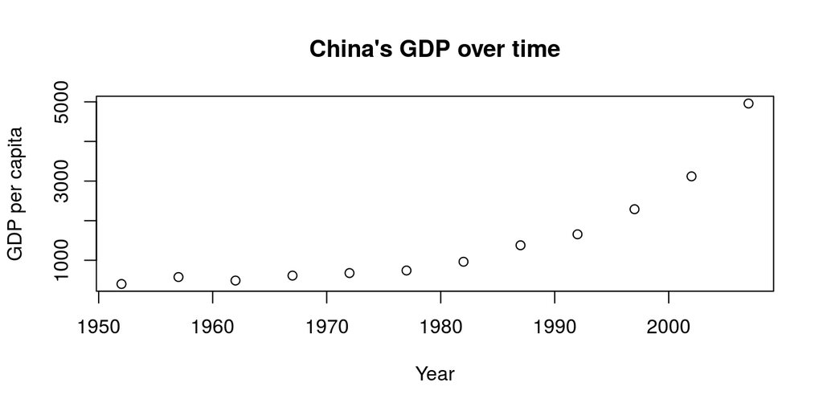

Second, we’re interested in Algeria’s GDP over time. We see that it **increased** in the 1970s, but **decreased** in the 1990s.

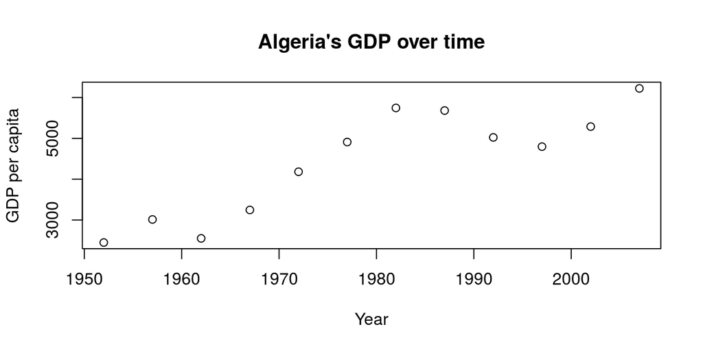

Lastly, we’re interested in France’s GDP over time. We see that it has been more or less **increasing linearly** over time.

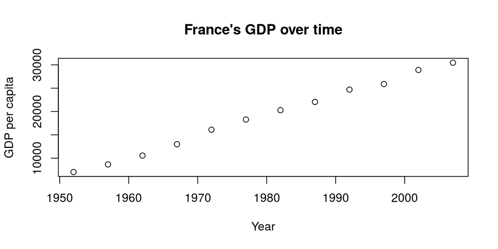

## Continental Summary

We see that, overall, life expectancies are lowest in Africa and highest in Oceania.

| Continent | Mean Life Expectancy | Min Life Expectancy | Max Life Expectancy |
| --- | --- | --- | --- |
| Africa | 48.87362 | 23.599 | 76.442 |
| Americas | 64.65874 | 37.579 | 80.653 |
| Asia | 60.06490 | 28.801 | 82.603 |
| Europe | 71.90369 | 43.585 | 81.757 |
| Oceania | 74.32621 | 69.120 | 81.235 |

## Histograms of global life expectancy

We see that life expectancy seems to be bimodal, with one peak near 70 years of age, and another, broader peak near 40 years of age. This is more apparent with narrower bin widths, since they illustrate the distribution a bit more precisely.

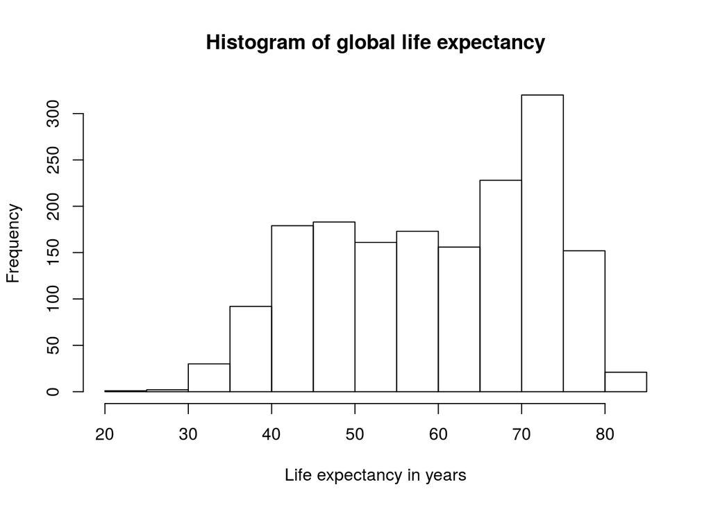

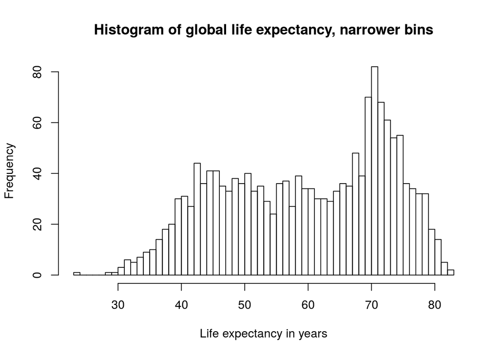